# INN_Learner_Notebook_Full_code_version

### 📍 Navegación

# Introduction to Neural Networks: Bank Churn prediction

## Problem Statement

### Context

Businesses like banks which provide service have to worry about problem of 'Customer Churn' i.e. customers leaving and joining another service provider. It is important to understand which aspects of the service influence a customer's decision in this regard. Management can concentrate efforts on improvement of service, keeping in mind these priorities.

### Objective

You as a Data scientist with the bank need to build a neural network based classifier that can determine whether a customer will leave the bank or not in the next 6 months.

### Data Dictionary:

- CustomerId: Unique ID which is assigned to each customer
- Surname: Last name of the customer
- CreditScore: It defines the credit history of the customer.
- Geography: A customer’s location
- Gender: It defines the Gender of the customer
- Age: Age of the customer
- Tenure: Number of years for which the customer has been with the bank
- NumOfProducts: refers to the number of products that a customer has purchased through the bank.
- Balance: Account balance
- HasCrCard: It is a categorical variable which decides whether the customer has credit card or not.
- EstimatedSalary: Estimated salary
- isActiveMember: Is is a categorical variable which decides whether the customer is active member of the bank or not ( Active member in the sense, using bank products regularly, making transactions etc )
- Exited : whether or not the customer left the bank within six month. It can take two values

** 0=No ( Customer did not leave the bank ) ** 1=Yes ( Customer left the bank )

## Importing necessary libraries

```python
from tensorflow.keras.layers import Dense, Dropout, InputLayer
from sklearn.metrics import classification_report, confusion_matrix
from tensorflow.keras import optimizers
from tensorflow.keras.models import Sequential
from tensorflow.keras import backend
from tensorflow.keras.wrappers.scikit_learn import KerasClassifier
from sklearn.preprocessing import StandardScaler
from sklearn.model_selection import train_test_split
from sklearn.metrics import roc_curve
from sklearn import metrics
from sklearn.model_selection import GridSearchCV
from imblearn.over_sampling import SMOTE
from keras import callbacks
import pandas as pd
import numpy as np
import matplotlib.pyplot as plt
import seaborn as sns
import tensorflow as tf
import warnings
warnings.filterwarnings("ignore")
```

## Loading the dataset

```python
from google.colab import drive
drive.mount('/content/drive/')
original_data = pd.read_csv("/content/drive/My Drive/5-DeepLearning/Project/Churn.csv")
data = original_data.copy()
```

```python
# Remove unnecessary columns 'RowNumber', 'CustomerId', and 'Surname'
data.drop(['RowNumber', 'CustomerId', 'Surname'], axis=1, inplace=True)
```

## Data Overview

```python
data.head()
```

|  | CreditScore | Geography | Gender | Age | Tenure | Balance | NumOfProducts | HasCrCard | IsActiveMember | EstimatedSalary | Exited |
| --- | --- | --- | --- | --- | --- | --- | --- | --- | --- | --- | --- |
| 0 | 619 | France | Female | 42 | 2 | 0.00 | 1 | 1 | 1 | 101348.88 | 1 |
| 1 | 608 | Spain | Female | 41 | 1 | 83807.86 | 1 | 0 | 1 | 112542.58 | 0 |
| 2 | 502 | France | Female | 42 | 8 | 159660.80 | 3 | 1 | 0 | 113931.57 | 1 |
| 3 | 699 | France | Female | 39 | 1 | 0.00 | 2 | 0 | 0 | 93826.63 | 0 |
| 4 | 850 | Spain | Female | 43 | 2 | 125510.82 | 1 | 1 | 1 | 79084.10 | 0 |

```python
data.tail()
```

|  | CreditScore | Geography | Gender | Age | Tenure | Balance | NumOfProducts | HasCrCard | IsActiveMember | EstimatedSalary | Exited |
| --- | --- | --- | --- | --- | --- | --- | --- | --- | --- | --- | --- |
| 9995 | 771 | France | Male | 39 | 5 | 0.00 | 2 | 1 | 0 | 96270.64 | 0 |
| 9996 | 516 | France | Male | 35 | 10 | 57369.61 | 1 | 1 | 1 | 101699.77 | 0 |
| 9997 | 709 | France | Female | 36 | 7 | 0.00 | 1 | 0 | 1 | 42085.58 | 1 |
| 9998 | 772 | Germany | Male | 42 | 3 | 75075.31 | 2 | 1 | 0 | 92888.52 | 1 |
| 9999 | 792 | France | Female | 28 | 4 | 130142.79 | 1 | 1 | 0 | 38190.78 | 0 |

```python
data.info()
```

```
<class 'pandas.core.frame.DataFrame'>
RangeIndex: 10000 entries, 0 to 9999
Data columns (total 11 columns):
 #   Column           Non-Null Count  Dtype
---  ------           --------------  -----
 0   CreditScore      10000 non-null  int64
 1   Geography        10000 non-null  object
 2   Gender           10000 non-null  object
 3   Age              10000 non-null  int64
 4   Tenure           10000 non-null  int64
 5   Balance          10000 non-null  float64
 6   NumOfProducts    10000 non-null  int64
 7   HasCrCard        10000 non-null  int64
 8   IsActiveMember   10000 non-null  int64
 9   EstimatedSalary  10000 non-null  float64
 10  Exited           10000 non-null  int64
dtypes: float64(2), int64(7), object(2)
memory usage: 859.5+ KB
```

```python
data.nunique()
```

```
CreditScore         460
Geography             3
Gender                2
Age                  70
Tenure               11
Balance            6382
NumOfProducts         4
HasCrCard             2
IsActiveMember        2
EstimatedSalary    9999
Exited                2
dtype: int64
```

```python
data.shape
```

```
(10000, 11)
```

```python
data.describe().T
```

|  | count | mean | std | min | 25% | 50% | 75% | max |
| --- | --- | --- | --- | --- | --- | --- | --- | --- |
| CreditScore | 10000.0 | 650.528800 | 96.653299 | 350.00 | 584.00 | 652.000 | 718.0000 | 850.00 |
| Age | 10000.0 | 38.921800 | 10.487806 | 18.00 | 32.00 | 37.000 | 44.0000 | 92.00 |
| Tenure | 10000.0 | 5.012800 | 2.892174 | 0.00 | 3.00 | 5.000 | 7.0000 | 10.00 |
| Balance | 10000.0 | 76485.889288 | 62397.405202 | 0.00 | 0.00 | 97198.540 | 127644.2400 | 250898.09 |
| NumOfProducts | 10000.0 | 1.530200 | 0.581654 | 1.00 | 1.00 | 1.000 | 2.0000 | 4.00 |
| HasCrCard | 10000.0 | 0.705500 | 0.455840 | 0.00 | 0.00 | 1.000 | 1.0000 | 1.00 |
| IsActiveMember | 10000.0 | 0.515100 | 0.499797 | 0.00 | 0.00 | 1.000 | 1.0000 | 1.00 |
| EstimatedSalary | 10000.0 | 100090.239881 | 57510.492818 | 11.58 | 51002.11 | 100193.915 | 149388.2475 | 199992.48 |
| Exited | 10000.0 | 0.203700 | 0.402769 | 0.00 | 0.00 | 0.000 | 0.0000 | 1.00 |

**CreditScore**:

- The mean credit score is approximately 650.53, with a standard deviation of 96.65.
- Credit scores range from a minimum of 350 to a maximum of 850.
- The distribution appears to be approximately symmetric, with a median (50th percentile) of 652.

**Age**:

- The average age of customers in the dataset is around 38.92 years, with a standard deviation of 10.49.
- Customer ages range from a minimum of 18 years to a maximum of 92 years.
- The age distribution seems to be slightly right-skewed, with the median (50th percentile) at 37 years.

**Tenure**:

- On average, customers have a tenure of approximately 5.01 years, with a standard deviation of 2.89.
- Tenure varies from a minimum of 0 years (possibly indicating new customers) to a maximum of 10 years.
- The distribution shows that most customers have tenures between 3 and 7 years.

**NumOfProducts**:

- Customers typically have 1.53 products on average, with a standard deviation of 0.58.
- The number of products per customer ranges from a minimum of 1 to a maximum of 4.
- The majority of customers have 1 or 2 products.

**HasCrCard**:

- About 70.55% of customers have a credit card (1), while the rest do not (0).
- This column is binary, indicating whether a customer has a credit card.

**IsActiveMember**:

- Approximately 51.51% of customers are active members (1), while the remaining 48.49% are not (0).
- This column represents whether a customer is an active member.

**EstimatedSalary**:

- The average estimated salary is approximately 100,090.24, with a standard deviation of 57,510.49.
- Estimated salaries range from a minimum of 11.58 to a maximum of 199,992.48.
- The distribution appears to be relatively uniform.

**Exited**:

- The "Exited" column is binary, indicating whether a customer has exited the service.
- About 20.37% of customers have exited (1), while the majority (79.63%) have not (0).

## Exploratory Data Analysis

- EDA is an important part of any project involving data.
- It is important to investigate and understand the data better before building a model with it.
- A few questions have been mentioned below which will help you approach the analysis in the right manner and generate insights from the data.
- A thorough analysis of the data, in addition to the questions mentioned below, should be done.

**Questions**:

1. What is the distribution of the credit score of customers? Are there any noticeable patterns or outliers in the distribution?
2. How many active members are there with the bank?
3. How are the different customer attributes correlated to each other?
4. Who is churning more when compared to males and females?
5. Customers from which geographical part are churning more?

```python
# function to plot a boxplot and a histogram along the same scale.


def histogram_boxplot(data, feature, figsize=(12, 7), kde=False, bins=None):
    """
    Boxplot and histogram combined

    data: dataframe
    feature: dataframe column
    figsize: size of figure (default (12,7))
    kde: whether to the show density curve (default False)
    bins: number of bins for histogram (default None)
    """
    f2, (ax_box2, ax_hist2) = plt.subplots(
        nrows=2,  # Number of rows of the subplot grid= 2
        sharex=True,  # x-axis will be shared among all subplots
        gridspec_kw={"height_ratios": (0.25, 0.75)},
        figsize=figsize,
    )  # creating the 2 subplots
    sns.boxplot(
        data=data, x=feature, ax=ax_box2, showmeans=True, color="violet"
    )  # boxplot will be created and a triangle will indicate the mean value of the column
    sns.histplot(
        data=data, x=feature, kde=kde, ax=ax_hist2, bins=bins, palette="winter"
    ) if bins else sns.histplot(
        data=data, x=feature, kde=kde, ax=ax_hist2
    )  # For histogram
    ax_hist2.axvline(
        data[feature].mean(), color="green", linestyle="--"
    )  # Add mean to the histogram
    ax_hist2.axvline(
        data[feature].median(), color="black", linestyle="-"
    )  # Add median to the histogram
```

```python
# function to create labeled barplots


def labeled_barplot(data, feature, perc=False, n=None):
    """
    Barplot with percentage at the top

    data: dataframe
    feature: dataframe column
    perc: whether to display percentages instead of count (default is False)
    n: displays the top n category levels (default is None, i.e., display all levels)
    """

    total = len(data[feature])  # length of the column
    count = data[feature].nunique()
    if n is None:
        plt.figure(figsize=(count + 1, 5))
    else:
        plt.figure(figsize=(n + 1, 5))

    plt.xticks(rotation=90, fontsize=15)
    ax = sns.countplot(
        data=data,
        x=feature,
        palette="Paired",
        order=data[feature].value_counts().index[:n].sort_values(),
    )

    for p in ax.patches:
        if perc == True:
            label = "{:.1f}%".format(
                100 * p.get_height() / total
            )  # percentage of each class of the category
        else:
            label = p.get_height()  # count of each level of the category

        x = p.get_x() + p.get_width() / 2  # width of the plot
        y = p.get_height()  # height of the plot

        ax.annotate(
            label,
            (x, y),
            ha="center",
            va="center",
            size=12,
            xytext=(0, 5),
            textcoords="offset points",
        )  # annotate the percentage

    plt.show()  # show the plot
```

```python
def bar_chart(x_name, y_name, title, labels, data):
    sns.set(style="darkgrid")
    plt.figure(figsize=(8, 6))
    sns.countplot(x=x_name, hue=y_name, data=data)
    plt.title(title)
    plt.xlabel(x_name)
    plt.ylabel("Count")
    plt.legend(title=y_name, labels=labels)
    plt.show()
```

1. What is the distribution of the credit score of customers? Are there any noticeable patterns or outliers in the distribution?

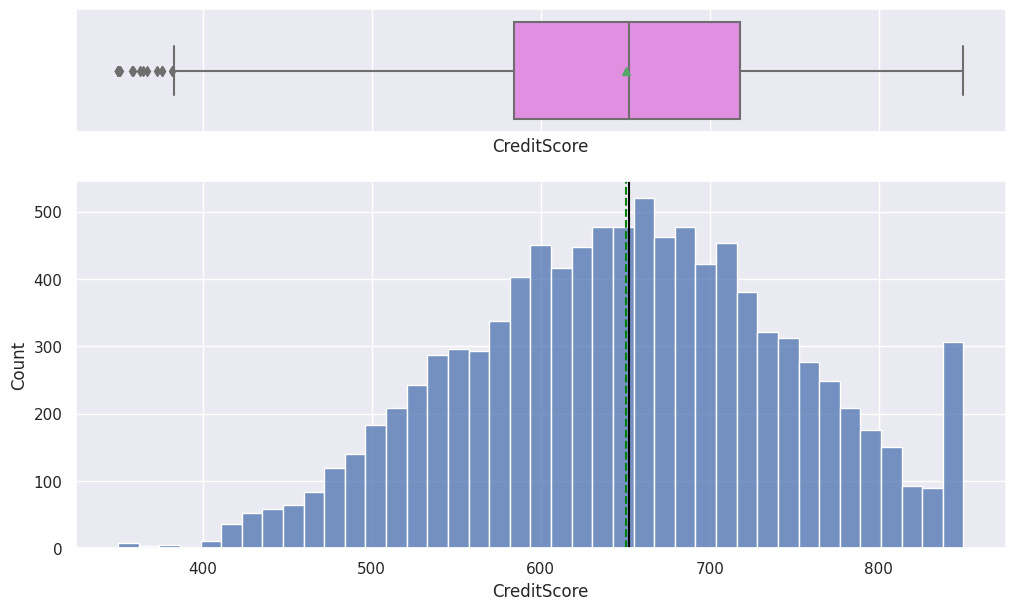

```python
# histogram_box plot
histogram_boxplot(data, "CreditScore")
```

#### Observations

It seems to be a left-skewed distribution.

2. How many active members are there with the bank?

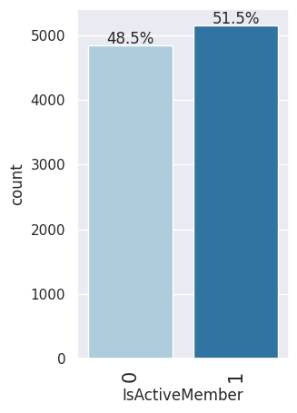

```python
# labeled bar plot
labeled_barplot(data, "IsActiveMember", perc=True)
```

```python
data['IsActiveMember'].eq(1).sum()
```

```
5151
```

#### Observations

Active members: 5151

3. How are the different customer attributes correlated to each other?

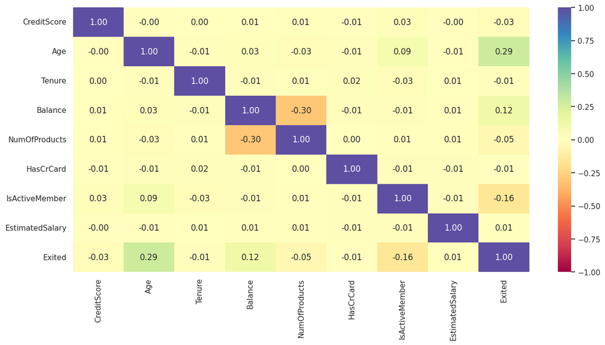

```python
columnas_numericas = data.select_dtypes(include=['number']).columns
plt.figure(figsize=(15, 7))
sns.heatmap(data[columnas_numericas].corr(), annot=True, vmin=-1,
            vmax=1, fmt=".2f", cmap="Spectral")
plt.show()
```

CreditScore vs. Age: There is a very weak negative correlation (-0.003965) between CreditScore and Age. This suggests that, on average, older customers do not necessarily have lower credit scores.

Age vs. Tenure: Age and Tenure have a weak negative correlation (-0.009997), implying that older customers tend to have slightly shorter tenures with the bank.

Balance vs. NumOfProducts: There is a significant negative correlation (-0.304180) between Balance and NumOfProducts, indicating that customers with more products tend to maintain lower account balances.

Age vs. IsActiveMember: Age and IsActiveMember have a positive correlation (0.085472), suggesting that older customers are slightly more likely to be active members.

NumOfProducts vs. Exited: NumOfProducts and Exited have a negative correlation (-0.047820), indicating that customers with more products are slightly less likely to exit the bank.

IsActiveMember vs. Exited: There is a moderate negative correlation (-0.156128) between IsActiveMember and Exited, suggesting that active members are less likely to churn.

Age vs. Exited: Age and Exited have a positive correlation (0.285323), indicating that older customers are more likely to exit the bank. This could be due to various factors, such as retirement or changing financial needs.

EstimatedSalary vs. Exited: There is a very weak positive correlation (0.012097) between EstimatedSalary and Exited, suggesting that there is no strong relationship between salary and customer churn.

CreditScore vs. Exited: CreditScore and Exited have a negative correlation (-0.027094), indicating that customers with lower credit scores are slightly more likely to exit the bank.

4. Who is churning more when compared to males and females?

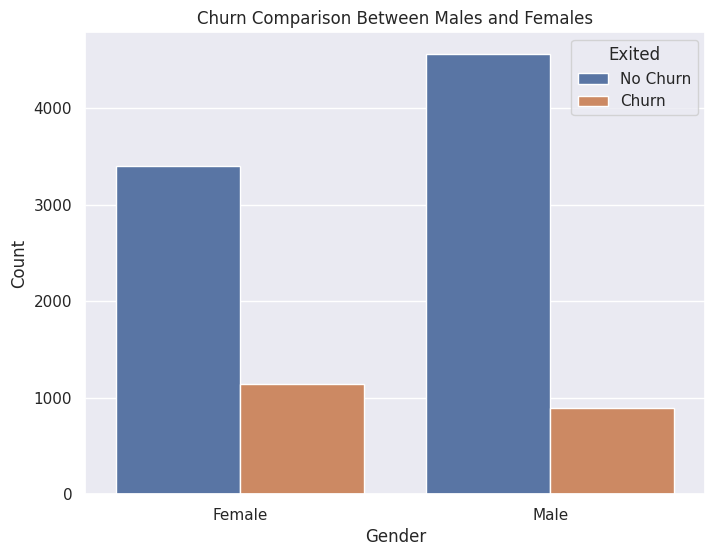

```python
bar_chart("Gender", "Exited", "Churn Comparison Between Males and Females", [
          "No Churn", "Churn"], data)
```

#### Observations

Females churn more than males

5. Customers from which geographical part are churning more?

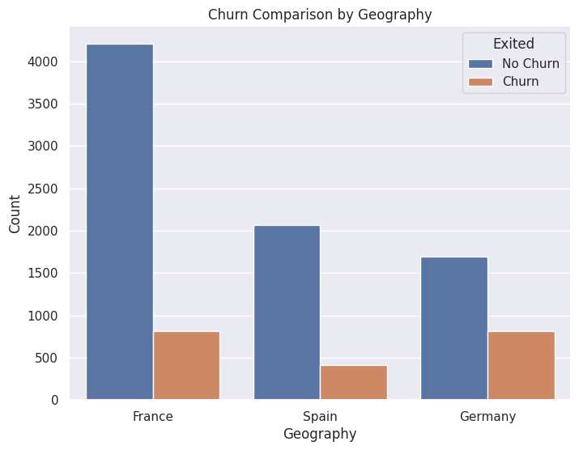

```python
bar_chart("Geography", "Exited", "Churn Comparison by Geography",
          ["No Churn", "Churn"], data)
```

#### Observations

Germany and France have similar churn values but both are above Spain

### Univariate analysis

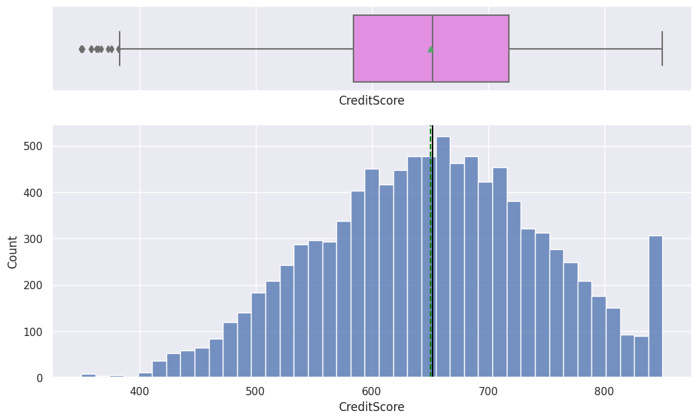

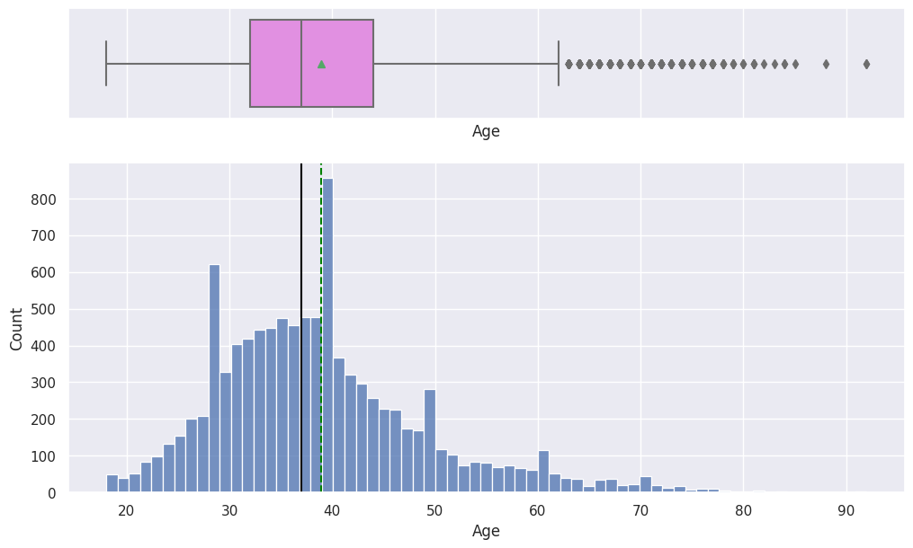

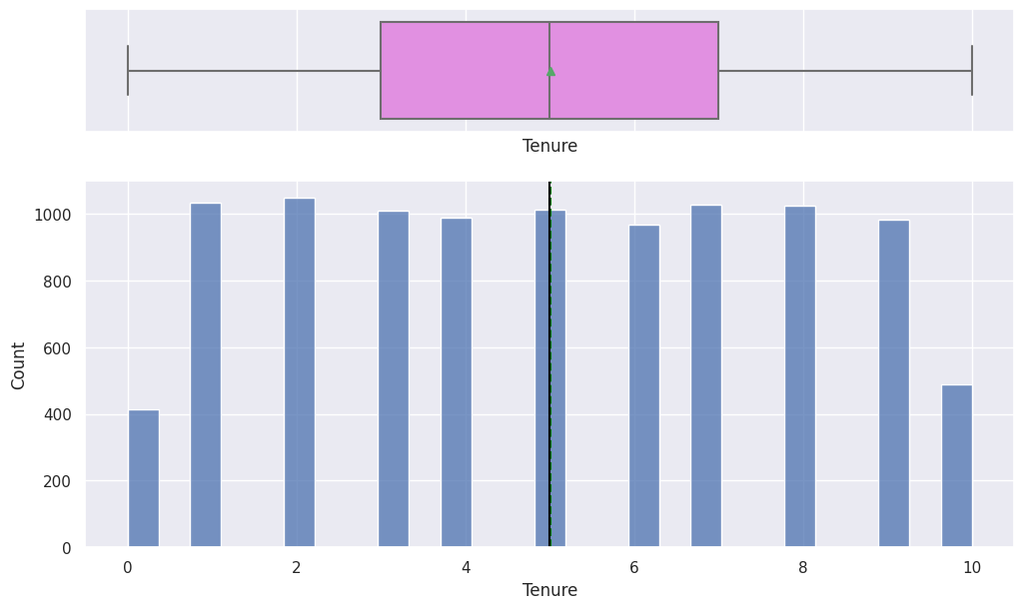

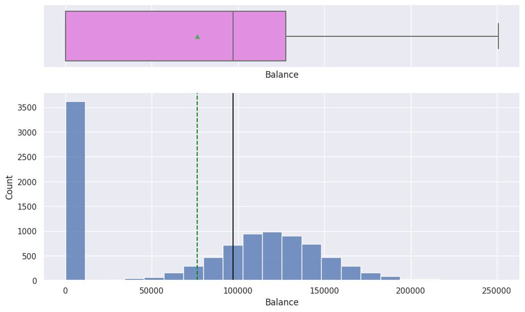

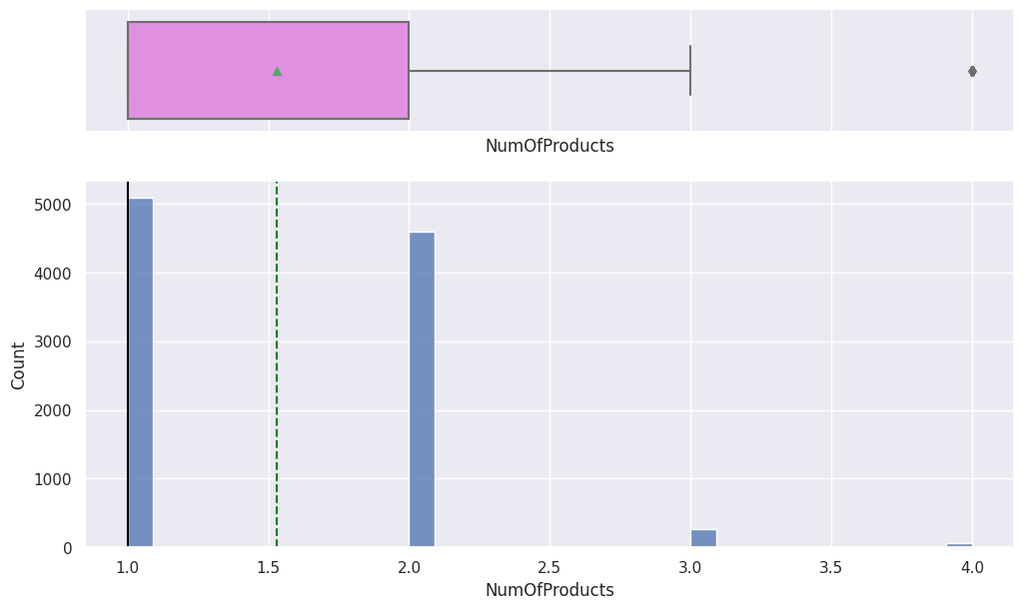

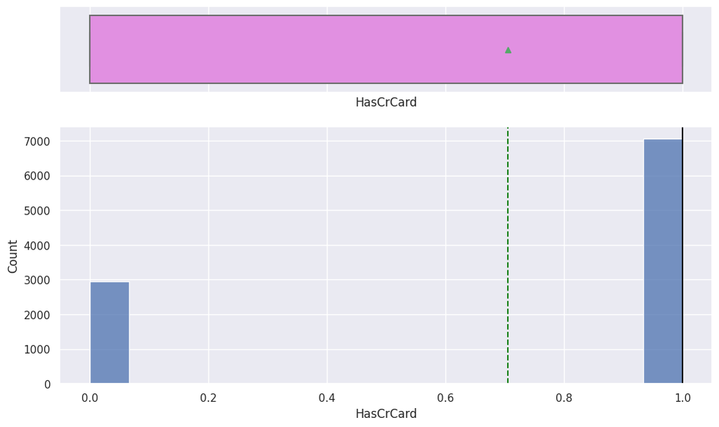

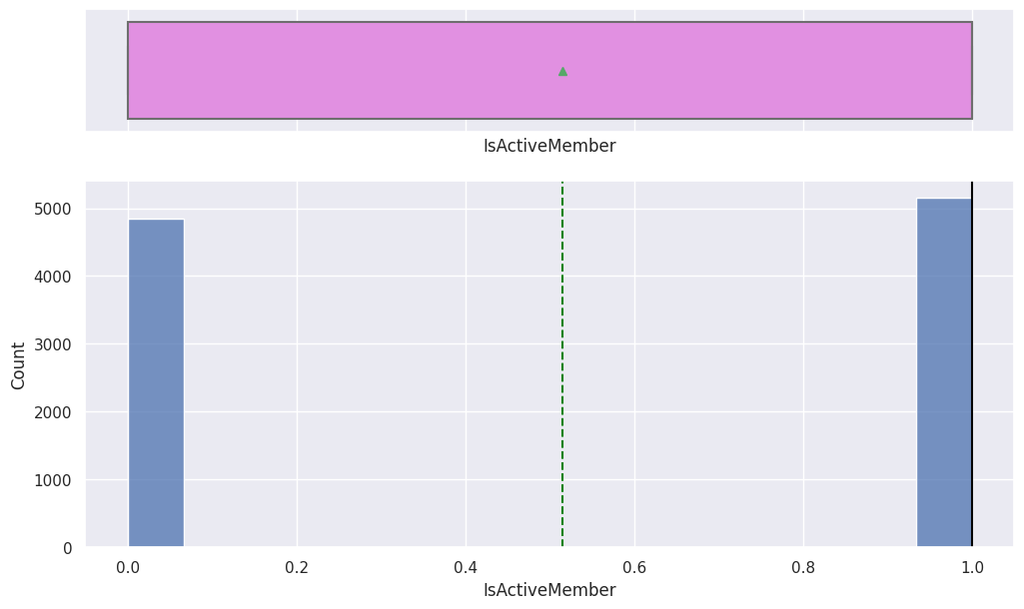

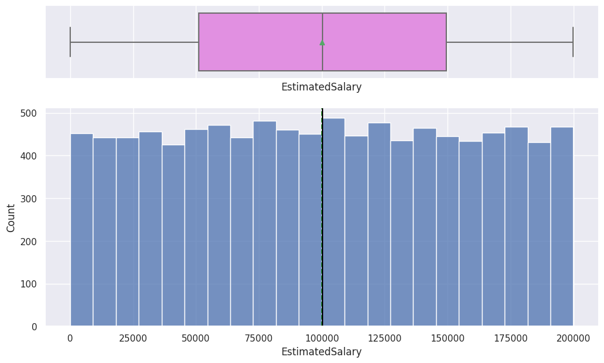

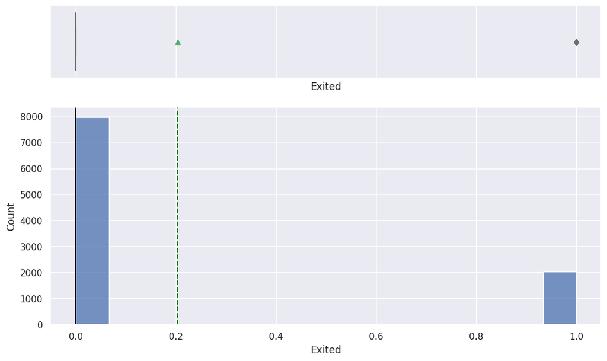

```python
# histogram_box plot for all the numerical values
for column in columnas_numericas:
    histogram_boxplot(data, column)
```

### Bivariate Analysis

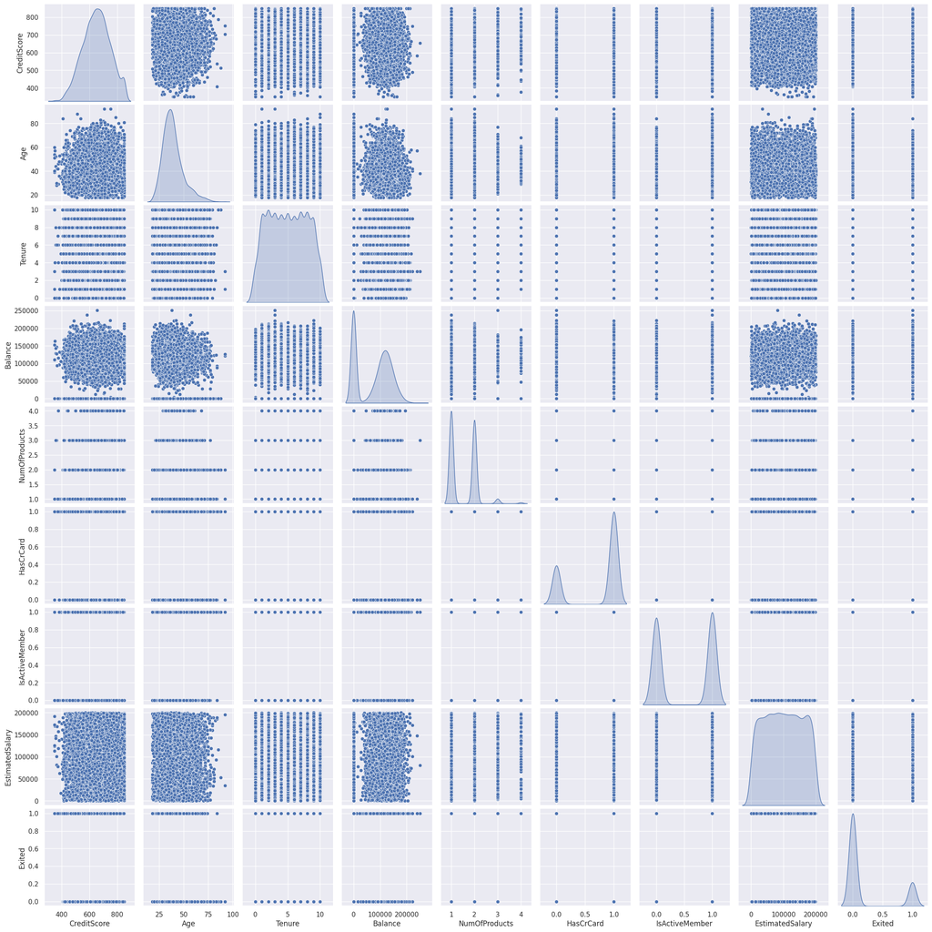

```python
sns.pairplot(data=data, diag_kind="kde")
```

## Data Preprocessing

- Missing value treatment
- Feature engineering (if needed)
- Outlier detection and treatment (if needed)
- Preparing data for modeling
- Any other preprocessing steps (if needed)

```python
# Duplicate value check
data.duplicated().sum()
```

```
0
```

#### Observations

There are no duplicated values

```python
# Checking missing values
data.isnull().sum()
```

```
CreditScore        0
Geography          0
Gender             0
Age                0
Tenure             0
Balance            0
NumOfProducts      0
HasCrCard          0
IsActiveMember     0
EstimatedSalary    0
Exited             0
dtype: int64
```

```python
# Checking missing values
data.isna().sum()
```

```
CreditScore        0
Geography          0
Gender             0
Age                0
Tenure             0
Balance            0
NumOfProducts      0
HasCrCard          0
IsActiveMember     0
EstimatedSalary    0
Exited             0
dtype: int64
```

#### Observations

There are no missing values

#### Outliers

```python
threshold = 3
outlier = {}
columnas_numericas = data.select_dtypes(include=['number']).columns
for col in columnas_numericas:
    i = data[col]
    mean = np.mean(data[col])
    std = np.std(data[col])
    list1 = []
    for v in i:
        z = (v - mean) / std
        if z > threshold:
            if v not in list1:
                list1.append(v)
    list1.sort()
    outlier[i.name] = list1

print("The following are the outliers in the data:")
for key, value in outlier.items():
    print("\n", key, ":", value)
```

```
The following are the outliers in the data:

 CreditScore : []

 Age : [71, 72, 73, 74, 75, 76, 77, 78, 79, 80, 81, 82, 83, 84, 85, 88, 92]

 Tenure : []

 Balance : []

 NumOfProducts : [4]

 HasCrCard : []

 IsActiveMember : []

 EstimatedSalary : []

 Exited : []
```

### Outlier Treatment

```python
# functions to treat outliers by flooring and capping


def treat_outliers(df, col):
    """
    Treats outliers in a variable

    df: dataframe
    col: dataframe column
    """
    Q1 = df[col].quantile(0.25)  # 25th quantile
    Q3 = df[col].quantile(0.75)  # 75th quantile
    IQR = Q3 - Q1
    Lower_Whisker = Q1 - 1.5 * IQR
    Upper_Whisker = Q3 + 1.5 * IQR

    # all the values smaller than Lower_Whisker will be assigned the value of Lower_Whisker
    # all the values greater than Upper_Whisker will be assigned the value of Upper_Whisker
    df[col] = np.clip(df[col], Lower_Whisker, Upper_Whisker)

    return df


def treat_outliers_all(df, col_list):
    """
    Treat outliers in a list of variables

    df: dataframe
    col_list: list of dataframe columns
    """
    for c in col_list:
        df = treat_outliers(df, c)

    return df
```

```python
new_data = treat_outliers_all(data, ['Age'])
```

### Checking the outliers

```python
threshold = 3
outlier = {}
columnas_numericas = new_data.select_dtypes(include=['number']).columns
for col in columnas_numericas:
    i = new_data[col]
    mean = np.mean(new_data[col])
    std = np.std(new_data[col])
    list1 = []
    for v in i:
        z = (v - mean) / std
        if z > threshold:
            if v not in list1:
                list1.append(v)
    list1.sort()
    outlier[i.name] = list1

print("The following are the outliers in the data:")
for key, value in outlier.items():
    print("\n", key, ":", value)
```

```
The following are the outliers in the data:

 CreditScore : []

 Age : []

 Tenure : []

 Balance : []

 NumOfProducts : [4]

 HasCrCard : []

 IsActiveMember : []

 EstimatedSalary : []

 Exited : []
```

### Preparing data for modeling

```python
# getting the features and labels and finally splitting the test and train data.
X = new_data.drop('Exited', axis=1)
Y = new_data['Exited']
```

```python
# Splitting the dataset into the Training and Testing set.
X_big, X_test, y_big, y_test = train_test_split(
    X, Y, test_size=0.1, random_state=5, shuffle=True)
```

```python
# Splitting the dataset into the Training and validation set.
X_train, X_val, y_train, y_val = train_test_split(
    X_big, y_big, test_size=0.3, random_state=5, shuffle=True)
```

```python
X_train.head()
```

|  | CreditScore | Geography | Gender | Age | Tenure | Balance | NumOfProducts | HasCrCard | IsActiveMember | EstimatedSalary |
| --- | --- | --- | --- | --- | --- | --- | --- | --- | --- | --- |
| 6222 | 582 | France | Male | 31 | 2 | 0.00 | 2 | 1 | 1 | 33747.03 |
| 4085 | 520 | France | Male | 34 | 4 | 134007.90 | 1 | 1 | 1 | 193209.11 |
| 6328 | 790 | Spain | Female | 41 | 7 | 109508.68 | 1 | 0 | 0 | 86776.38 |
| 2594 | 537 | Germany | Female | 47 | 6 | 103163.35 | 1 | 1 | 0 | 16259.64 |
| 9987 | 606 | Spain | Male | 30 | 8 | 180307.73 | 2 | 1 | 1 | 1914.41 |

```python
# Scaling the data
columns_to_scale = ['CreditScore', 'Age', 'Tenure',
                    'Balance', 'NumOfProducts', 'EstimatedSalary']
sc = StandardScaler()
temp = sc.fit(X_train[columns_to_scale])
X_train[columns_to_scale] = temp.transform(X_train[columns_to_scale])
X_test[columns_to_scale] = temp.transform(X_test[columns_to_scale])
X_val[columns_to_scale] = temp.transform(X_val[columns_to_scale])
```

```python
# Using pd.get dummies to encode the categorical columns in the data
cat_data = ['Geography', 'Gender']
X_train = pd.get_dummies(X_train, columns=cat_data, drop_first=True)
X_test = pd.get_dummies(X_test, columns=cat_data, drop_first=True)
X_val = pd.get_dummies(X_val, columns=cat_data, drop_first=True)
```

```python
# Checking the shape
print(X_train.shape)
print(X_val.shape)
print(X_test.shape)
print(y_train.shape)
print(y_val.shape)
print(y_test.shape)
```

```
(6300, 11)
(2700, 11)
(1000, 11)
(6300,)
(2700,)
(1000,)
```

```python
# Checking the head()
print('X_train \n')
print(X_train.head())
print('\n y_train \n')
print(y_train.head())
```

```
X_train

      CreditScore       Age    Tenure   Balance  NumOfProducts  HasCrCard  \
6222    -0.705093 -0.786348 -1.038141 -1.230161       0.823097          1
4085    -1.346339 -0.476666 -0.346669  0.924816      -0.902531          1
6328     1.446183  0.245927  0.690539  0.530844      -0.902531          0
2594    -1.170513  0.865293  0.344803  0.428805      -0.902531          1
9987    -0.456869 -0.889576  1.036275  1.669362       0.823097          1

      IsActiveMember  EstimatedSalary  Geography_Germany  Geography_Spain  \
6222               1        -1.158081                  0                0
4085               1         1.620116                  0                0
6328               0        -0.234188                  0                1
2594               0        -1.462752                  1                0
9987               1        -1.712679                  0                1

      Gender_Male
6222            1
4085            1
6328            0
2594            0
9987            1

 y_train

6222    0
4085    0
6328    0
2594    1
9987    0
Name: Exited, dtype: int64
```

## Model Building

### Model Evaluation Criterion

It's important to consider the potential consequences of making wrong predictions. Two common prediction errors are:

False Positive: Predicting that a customer is exiting (Class 1) when they are not actually exiting (Class 0).

False Negative: Predicting that a customer is not exiting (Class 0) when they are actually exiting (Class 1).

Among these two errors, the more important one for the bank to minimize is the False Negative. Here's why:

Importance of Minimizing False Negatives:

Predicting that a customer is not exiting when they are actually leaving the bank can have significant financial consequences. In such cases, the bank may miss the opportunity to take proactive measures to retain those customers. These customers might be sensitive or dissatisfied for various reasons, and if their issues are not addressed promptly, they could leave, resulting in revenue loss for the bank.

Reducing False Negatives (Increasing Recall):

To reduce the risk of false negatives and increase Recall, which is the proportion of actual positives (churn cases) correctly predicted by the model, the bank can consider the following strategies:

Threshold Adjustment: By adjusting the classification threshold for the churn prediction model, you can increase sensitivity (recall) at the cost of specificity (precision). Lowering the threshold will classify more cases as positive (Class 1), which can help capture more true positives.

Feature Engineering: Carefully select and engineer features that are strong indicators of potential churn. Feature selection and extraction techniques can help improve the model's ability to identify at-risk customers.

Data Augmentation: Augment the dataset with additional data if possible. More data can help the model better capture the complexities of customer behavior and churn patterns.

Balancing the Dataset: If the dataset is imbalanced (i.e., there are far more non-churn cases than churn cases), consider techniques like oversampling the minority class (churn) or using synthetic data generation methods to balance the classes.

In summary, while both false positives and false negatives have their implications, in the context of customer churn prediction for a bank, minimizing false negatives (increasing Recall) is typically more critical. This ensures that the bank can proactively retain customers who are actually at risk of leaving, ultimately reducing revenue loss and maintaining customer loyalty.

### Model Building: Neural Network

```python
def make_confusion_matrix(cf,
                          group_names=None,
                          categories='auto',
                          count=True,
                          percent=True,
                          cbar=True,
                          xyticks=True,
                          xyplotlabels=True,
                          sum_stats=True,
                          figsize=None,
                          cmap='Blues',
                          title=None):
    '''
    This function will make a pretty plot of an sklearn Confusion Matrix cm using a Seaborn heatmap visualization.
    Arguments
    '''

    # CODE TO GENERATE TEXT INSIDE EACH SQUARE
    blanks = ['' for i in range(cf.size)]

    if group_names and len(group_names) == cf.size:
        group_labels = ["{}\n".format(value) for value in group_names]
    else:
        group_labels = blanks

    if count:
        group_counts = ["{0:0.0f}\n".format(value) for value in cf.flatten()]
    else:
        group_counts = blanks

    if percent:
        group_percentages = ["{0:.2%}".format(
            value) for value in cf.flatten()/np.sum(cf)]
    else:
        group_percentages = blanks

    box_labels = [f"{v1}{v2}{v3}".strip() for v1, v2, v3 in zip(
        group_labels, group_counts, group_percentages)]
    box_labels = np.asarray(box_labels).reshape(cf.shape[0], cf.shape[1])

    # CODE TO GENERATE SUMMARY STATISTICS & TEXT FOR SUMMARY STATS
    if sum_stats:
        # Accuracy is sum of diagonal divided by total observations
        accuracy = np.trace(cf) / float(np.sum(cf))

        # if it is a binary confusion matrix, show some more stats
        if len(cf) == 2:
            # Metrics for Binary Confusion Matrices
            precision = cf[1, 1] / sum(cf[:, 1])
            recall = cf[1, 1] / sum(cf[1, :])
            f1_score = 2*precision*recall / (precision + recall)
            stats_text = "\n\nAccuracy={:0.3f}\nPrecision={:0.3f}\nRecall={:0.3f}\nF1 Score={:0.3f}".format(
                accuracy, precision, recall, f1_score)
        else:
            stats_text = "\n\nAccuracy={:0.3f}".format(accuracy)
    else:
        stats_text = ""

    # SET FIGURE PARAMETERS ACCORDING TO OTHER ARGUMENTS
    if figsize == None:
        # Get default figure size if not set
        figsize = plt.rcParams.get('figure.figsize')

    if xyticks == False:
        # Do not show categories if xyticks is False
        categories = False

    # MAKE THE HEATMAP VISUALIZATION
    plt.figure(figsize=figsize)
    sns.heatmap(cf, annot=box_labels, fmt="", cmap=cmap, cbar=cbar,
                xticklabels=categories, yticklabels=categories)

    if xyplotlabels:
        plt.ylabel('True label')
        plt.xlabel('Predicted label' + stats_text)
    else:
        plt.xlabel(stats_text)

    if title:
        plt.title(title)
```

```python
def graphs_and_report(history, predicted):
    # Plot training & validation loss values
    plt.plot(history.history['loss'])
    plt.plot(history.history['val_loss'])
    plt.title('Model loss')
    plt.ylabel('Loss')
    plt.xlabel('Epoch')
    plt.legend(['Train', 'Test'], loc='upper left')
    plt.show()

    # Plot training & validation accuracy values
    plt.plot(history.history['accuracy'])
    plt.plot(history.history['val_accuracy'])
    plt.title('Model accuracy')
    plt.ylabel('Accuracy')
    plt.xlabel('Epoch')
    plt.legend(['Train', 'Test'], loc='upper left')
    plt.show()
```

### Model 1

```python
import random
backend.clear_session()
# Fixing the seed for random number generators so that we can ensure we receive the same output everytime
np.random.seed(42)
random.seed(42)
tf.random.set_seed(42)
```

```python
# Initializing the neural network model using the Sequential API
model1 = Sequential()

# Adding the input layer with 11 neurons and ReLU activation function
model1.add(Dense(11, activation='relu',
                 kernel_initializer='he_uniform', input_shape=(11,)))

# Adding the first hidden layer with 64 neurons and ReLU activation function
model1.add(Dense(64, activation='relu', kernel_initializer='he_uniform'))

# Adding the second hidden layer with 32 neurons and ReLU activation function
model1.add(Dense(32, activation='relu', kernel_initializer='he_uniform'))

# Adding the output layer with one neuron and sigmoid activation function
model1.add(Dense(1, activation='sigmoid'))

# Setting Stochastic Gradient Descent (SGD) as the optimizer with a learning rate of 1e-3
sgd = optimizers.SGD(learning_rate=1e-3)

# Compiling the model with binary cross-entropy loss and accuracy as the evaluation metric
model1.compile(optimizer=sgd, loss='binary_crossentropy', metrics=['accuracy'])

# Printing a summary of the model architecture
model1.summary()
```

```
Model: "sequential"
_________________________________________________________________
 Layer (type)                Output Shape              Param #
=================================================================
 dense (Dense)               (None, 11)                132

 dense_1 (Dense)             (None, 64)                768

 dense_2 (Dense)             (None, 32)                2080

 dense_3 (Dense)             (None, 1)                 33

=================================================================
Total params: 3,013
Trainable params: 3,013
Non-trainable params: 0
_________________________________________________________________
```

```python
# Training model1 on the training data (X_train, y_train) with validation data (X_val, y_val)
# for 100 epochs with a batch size of 32. The training history is stored in the 'history1' variable.
history1 = model1.fit(X_train, y_train, validation_data=(X_val, y_val), epochs=100, batch_size=32)
```

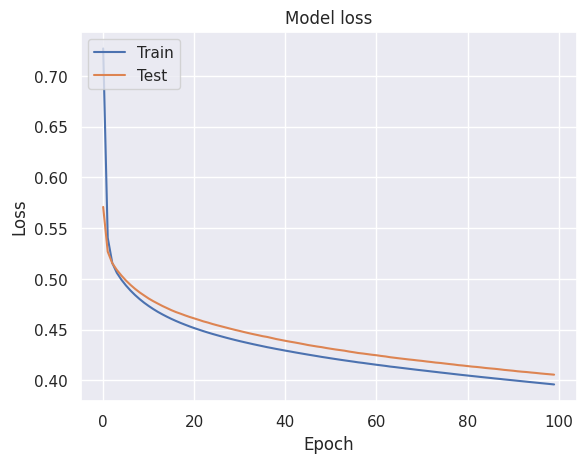

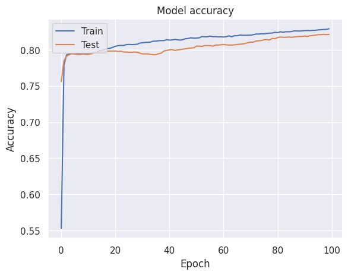

```python
# Predicting target values (y_pred1) using 'model1' on validation data (X_val).
y_pred1 = model1.predict(X_val)


# Let's predict using default threshold
y_pred1 = (y_pred1 > 0.5)

graphs_and_report(history1, y_pred1)
```

```python
# Classification report
cr1 = metrics.classification_report(y_val, y_pred1,digits=3)
print(cr1)
```

```
              precision    recall  f1-score   support

           0      0.839     0.959     0.895      2147
           1      0.645     0.286     0.396       553

    accuracy                          0.821      2700
   macro avg      0.742     0.623     0.646      2700
weighted avg      0.799     0.821     0.793      2700
```

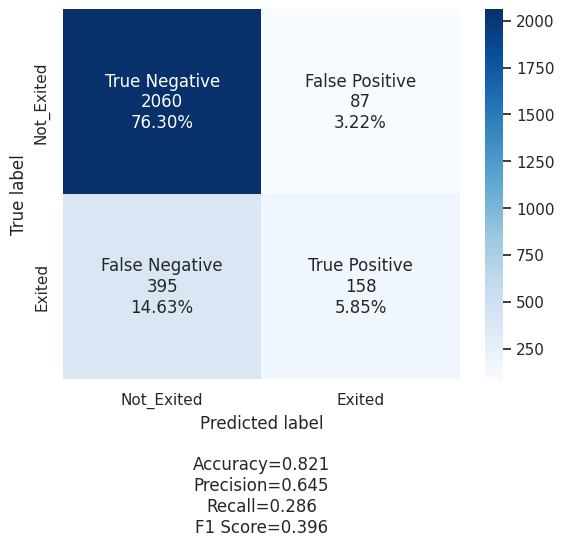

```python
# Confusion matrix
cm1 = confusion_matrix(y_val, y_pred1)
labels = ['True Negative', 'False Positive', 'False Negative', 'True Positive']
categories = ['Not_Exited', 'Exited']
make_confusion_matrix(cm1,
                      group_names=labels,
                      categories=categories,
                      cmap='Blues')
```

### Observations

Precision (0): 0.839

- Precision measures the accuracy of positive predictions for class 0. In this case, it indicates that when the model predicts class 0, it's usually correct.

Recall (0): 0.959

- Recall (or Sensitivity) measures the ability of the model to correctly identify actual class 0 instances. It tells us what proportion of actual class 0 cases were correctly predicted.

F1-Score (0): 0.895

- The F1-Score is the harmonic mean of precision and recall for class 0. It provides a balance between precision and recall for this class.

Precision (1): 0.645

- Precision for class 1. Indicates how accurate the model's positive predictions are for class 1.

Recall (1): 0.286

- Recall for class 1. Measures the ability to correctly identify actual class 1 instances.

F1-Score (1): 0.396

- F1-Score for class 1. Similar to class 0, it balances precision and recall for class 1.

### Model 2

```python
def best_threshold(model):
    # predict probabilities
    yhat = model.predict(X_train)
    # keep probabilities for the positive outcome only
    yhat = yhat[:, 0]
    # calculate roc curves
    fpr, tpr, thresholds = roc_curve(y_train, yhat)
    # calculate the g-mean for each threshold
    gmeans = np.sqrt(tpr * (1-fpr))
    # locate the index of the largest g-mean
    ix = np.argmax(gmeans)
    print('Best Threshold=%f, G-Mean=%.3f' % (thresholds[ix], gmeans[ix]))
    # plot the roc curve for the model
    plt.plot([0, 1], [0, 1], linestyle='--', label='No Skill')
    plt.plot(fpr, tpr, marker='.', label='Logistic')
    plt.scatter(fpr[ix], tpr[ix], marker='o', color='black', label='Best')
    # axis labels
    plt.xlabel('False Positive Rate')
    plt.ylabel('True Positive Rate')
    plt.legend()
    return thresholds[ix]
    # show the plot
    plt.show()
```

```python
import random
backend.clear_session()
# Fixing the seed for random number generators so that we can ensure we receive the same output everytime
np.random.seed(42)
random.seed(42)
tf.random.set_seed(42)
```

```python
# Initializing the neural network model using the Sequential API
model2 = Sequential()

# Adding the input layer with 64 neurons and ReLU activation function
model2.add(Dense(64, activation='relu',
                 kernel_initializer='he_uniform', input_shape=(11,)))

# Adding the second hidden layer with 32 neurons and ReLU activation function
model2.add(Dense(32, activation='relu', kernel_initializer='he_uniform'))

# Adding the output layer with one neuron and sigmoid activation function
model2.add(Dense(1, activation='sigmoid'))

# Setting Stochastic Gradient Descent (SGD) as the optimizer with a learning rate of 1e-3
sgd = optimizers.SGD(learning_rate=1e-3)

# Compiling the model with binary cross-entropy loss and accuracy as the evaluation metric
model2.compile(optimizer=sgd, loss='binary_crossentropy', metrics=['accuracy'])

# Printing a summary of the model architecture
model2.summary()
```

```
Model: "sequential"
_________________________________________________________________
 Layer (type)                Output Shape              Param #
=================================================================
 dense (Dense)               (None, 64)                768

 dense_1 (Dense)             (None, 32)                2080

 dense_2 (Dense)             (None, 1)                 33

=================================================================
Total params: 2,881
Trainable params: 2,881
Non-trainable params: 0
_________________________________________________________________
```

```python
# Training 'model2' on the training data (X_train, y_train) with validation data (X_val, y_val)
# for 100 epochs with a batch size of 32. The training history is stored in the 'history2' variable.
history2 = model2.fit(X_train, y_train, validation_data=(X_val, y_val), epochs=100, batch_size=32)
```

### Tune the threshold using ROC-AUC

```
Best Threshold=0.191838, G-Mean=0.736
```

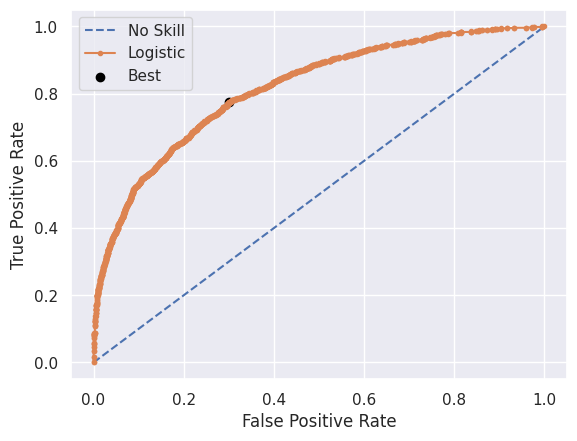

```python
threshold2 = best_threshold(model2)
```

### Loss and accuracy

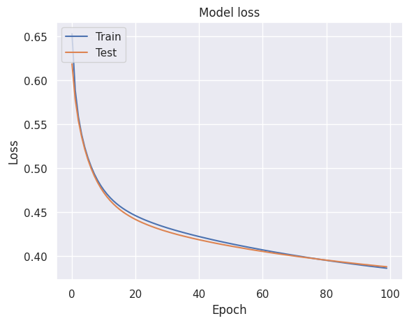

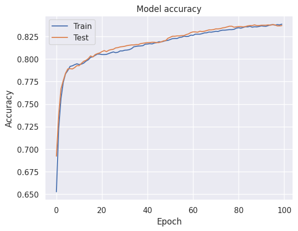

```python
# Predicting target values (y_pred2) using 'model2' on validation data (X_val)
y_pred2 = model2.predict(X_val)

# Applying a threshold to binary classification predictions
y_pred2 = (y_pred2 > threshold2)

graphs_and_report(history2, y_pred2)
```

### Classification report

```python
cr2 = metrics.classification_report(y_val, y_pred2,digits=3)
print(cr2)
```

```
              precision    recall  f1-score   support

           0      0.924     0.705     0.799      2147
           1      0.403     0.774     0.530       553

    accuracy                          0.719      2700
   macro avg      0.663     0.739     0.665      2700
weighted avg      0.817     0.719     0.744      2700
```

### Confusion matrix

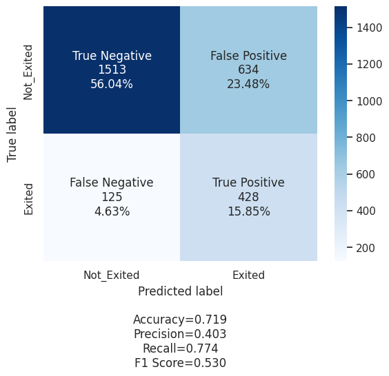

```python
cm2 = confusion_matrix(y_val, y_pred2)
labels = ['True Negative', 'False Positive', 'False Negative', 'True Positive']
categories = ['Not_Exited', 'Exited']
make_confusion_matrix(cm2,
                      group_names=labels,
                      categories=categories,
                      cmap='Blues')
```

### Observations

Precision (0): 0.924

- Precision measures the accuracy of positive predictions for class 0. In this case, it indicates that when the model predicts class 0, it's usually correct.

Recall (0): 0.705

- Recall (or Sensitivity) measures the ability of the model to correctly identify actual class 0 instances. It tells us what proportion of actual class 0 cases were correctly predicted.

F1-Score (0): 0.799

- The F1-Score is the harmonic mean of precision and recall for class 0. It provides a balance between precision and recall for this class.

Precision (1): 0.403

- Precision for class 1. Indicates how accurate the model's positive predictions are for class 1.

Recall (1): 0.774

- Recall for class 1. Measures the ability to correctly identify actual class 1 instances.

F1-Score (1): 0.530

- F1-Score for class 1. Similar to class 0, it balances precision and recall for class 1.

### Model Building: Neural Network model with Adam Optimizer

### Model 3

```python
import random
backend.clear_session()
# Fixing the seed for random number generators so that we can ensure we receive the same output everytime
np.random.seed(42)
random.seed(42)
tf.random.set_seed(42)
```

```python
# Initializing the neural network model using the Sequential API
model3 = Sequential()

# Adding the input layer with 64 neurons and ReLU activation function
model3.add(Dense(64, activation='relu',
                 kernel_initializer='he_uniform', input_shape=(11,)))

# Adding the second hidden layer with 32 neurons and ReLU activation function
model3.add(Dense(32, activation='relu', kernel_initializer='he_uniform'))

# Adding the output layer with one neuron and sigmoid activation function
model3.add(Dense(1, activation='sigmoid'))

# Initializing the Adam optimizer with a learning rate of 1e-3
adam = optimizers.Adam(learning_rate=1e-3)

# Compiling the model with binary cross-entropy loss and accuracy as the evaluation metric
model3.compile(optimizer=adam, loss='binary_crossentropy', metrics=['accuracy'])

# Printing a summary of the model architecture
model3.summary()
```

```
Model: "sequential"
_________________________________________________________________
 Layer (type)                Output Shape              Param #
=================================================================
 dense (Dense)               (None, 64)                768

 dense_1 (Dense)             (None, 32)                2080

 dense_2 (Dense)             (None, 1)                 33

=================================================================
Total params: 2,881
Trainable params: 2,881
Non-trainable params: 0
_________________________________________________________________
```

```python
history3 = model3.fit(X_train, y_train, validation_data=(
    X_val, y_val), epochs=100, batch_size=32)
```

### Tune the threshold using ROC-AUC

```
Best Threshold=0.247884, G-Mean=0.879
```

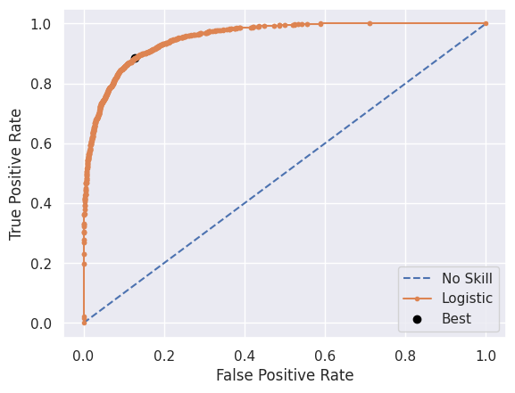

```python
threshold3 = best_threshold(model3)
```

### Loss and accuracy

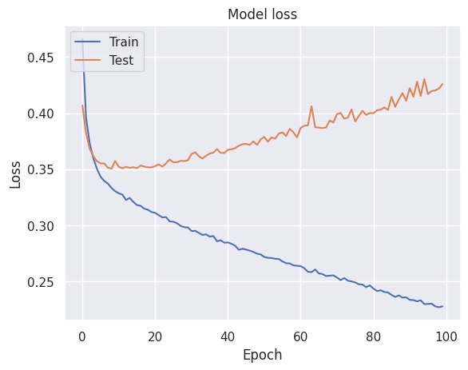

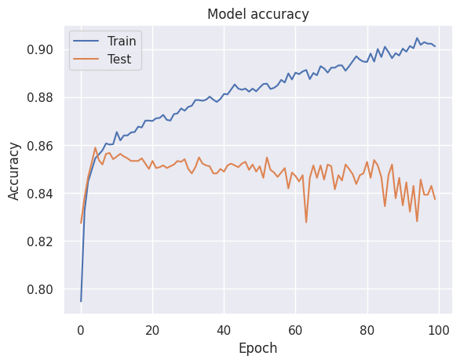

```python
# Predicting target values (y_pred3) using 'model3' on the validation data (X_val).
y_pred3 = model3.predict(X_val)

# Applying a threshold to the predictions.
y_pred3 = (y_pred3 > threshold3)

graphs_and_report(history3, y_pred3)
```

### Classification report

```python
# Classification report
cr3 = metrics.classification_report(y_val, y_pred3,digits=3)
print(cr3)
```

```
              precision    recall  f1-score   support

           0      0.911     0.821     0.863      2147
           1      0.497     0.687     0.577       553

    accuracy                          0.793      2700
   macro avg      0.704     0.754     0.720      2700
weighted avg      0.826     0.793     0.805      2700
```

### Confusion matrix

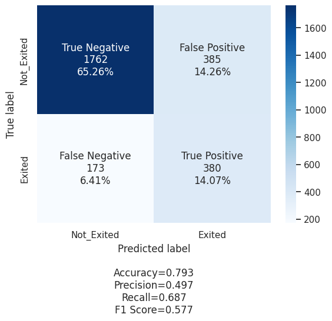

```python
cm3 = confusion_matrix(y_val, y_pred3)
labels = ['True Negative', 'False Positive', 'False Negative', 'True Positive']
categories = ['Not_Exited', 'Exited']
make_confusion_matrix(cm3,
                      group_names=labels,
                      categories=categories,
                      cmap='Blues')
```

# Classification Report:

Precision (0): 0.911

- Precision measures the accuracy of positive predictions for class 0. In this case, it indicates that when the model predicts class 0, it's usually correct.

Recall (0): 0.821

- Recall (or Sensitivity) measures the ability of the model to correctly identify actual class 0 instances. It tells us what proportion of actual class 0 cases were correctly predicted.

F1-Score (0): 0.863

- The F1-Score is the harmonic mean of precision and recall for class 0. It provides a balance between precision and recall for this class.

Precision (1): 0.497

- Precision for class 1. Indicates how accurate the model's positive predictions are for class 1.

Recall (1): 0.687

- Recall for class 1. Measures the ability to correctly identify actual class 1 instances.

F1-Score (1): 0.577

- F1-Score for class 1. Similar to class 0, it balances precision and recall for class 1.

### Model Improvement: Neural Network model with Dropout

### Model 4

```python
import random
backend.clear_session()
# Fixing the seed for random number generators so that we can ensure we receive the same output everytime
np.random.seed(42)
random.seed(42)
tf.random.set_seed(42)
```

```python
# Initializing the neural network model 'model4'
model4 = Sequential()

# Adding the input layer with 64 neurons and ReLU as the activation function
model4.add(Dense(64, activation='relu', kernel_initializer='he_uniform', input_shape=(11,)))

# Adding a dropout layer with a dropout rate of 20% to prevent overfitting
model4.add(Dropout(0.2))

# Adding the second hidden layer with 32 neurons and ReLU as the activation function
model4.add(Dense(32, activation='relu', kernel_initializer='he_uniform'))

# Adding another dropout layer with a dropout rate of 20%
model4.add(Dropout(0.2))

# Adding the output layer with one neuron and sigmoid as the activation function
model4.add(Dense(1, activation='sigmoid'))

# Defining the stochastic gradient descent (SGD) optimizer with a learning rate of 1e-3
sgd = optimizers.SGD(learning_rate=1e-3)

# Compiling the model using binary cross-entropy loss and accuracy as a metric
model4.compile(optimizer=sgd, loss='binary_crossentropy', metrics=['accuracy'])

# Printing a summary of the model architecture
model4.summary()
```

```
Model: "sequential"
_________________________________________________________________
 Layer (type)                Output Shape              Param #
=================================================================
 dense (Dense)               (None, 64)                768

 dropout (Dropout)           (None, 64)                0

 dense_1 (Dense)             (None, 32)                2080

 dropout_1 (Dropout)         (None, 32)                0

 dense_2 (Dense)             (None, 1)                 33

=================================================================
Total params: 2,881
Trainable params: 2,881
Non-trainable params: 0
_________________________________________________________________
```

### Adding early stop

```python
# Define early stopping criteria to prevent overfitting
early_stop = callbacks.EarlyStopping(
    monitor='val_loss', min_delta=0.001, patience=5)

# Train 'model4' on the training data (X_train, y_train) with validation data (X_val, y_val)
# for a maximum of 100 epochs with a batch size of 32.
# Early stopping will be applied based on validation loss, with a patience of 5 epochs.
history4 = model4.fit(X_train, y_train, validation_data=(X_val, y_val), epochs=100, batch_size=32, callbacks=[early_stop])
```

### Tune the threshold using ROC-AUC

```
Best Threshold=0.224817, G-Mean=0.715
```

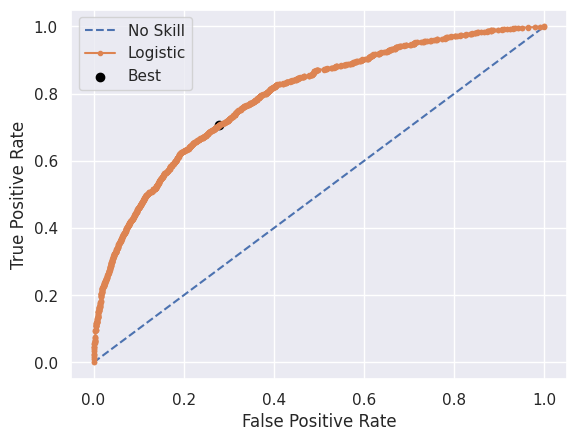

```python
threshold4 = best_threshold(model4)
```

### Loss and accuracy

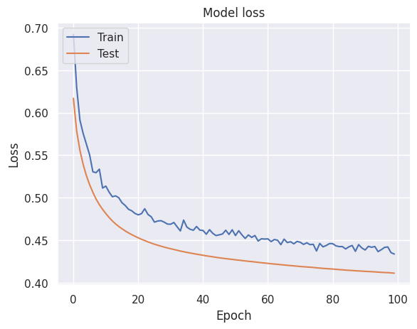

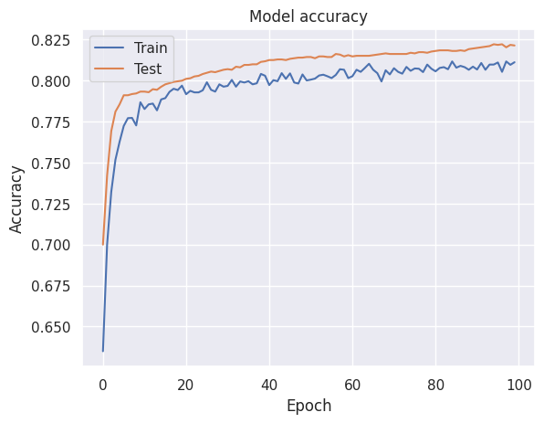

```python
# Predicting target values (y_pred4) using 'model4' on the validation data (X_val).
y_pred4 = model4.predict(X_val)

# Applying a threshold to the predictions.
y_pred4 = (y_pred4 > threshold4)

graphs_and_report(history4, y_pred4)
```

### Classification report

```python
cr4 = metrics.classification_report(y_val, y_pred4)
print(cr4)
```

```
              precision    recall  f1-score   support

           0       0.92      0.73      0.81      2147
           1       0.42      0.76      0.54       553

    accuracy                           0.73      2700
   macro avg       0.67      0.74      0.68      2700
weighted avg       0.82      0.73      0.76      2700
```

### Confusion matrix

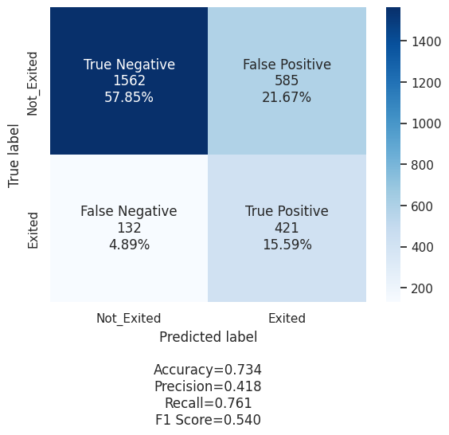

```python
cm4 = confusion_matrix(y_val, y_pred4)
labels = ['True Negative', 'False Positive', 'False Negative', 'True Positive']
categories = ['Not_Exited', 'Exited']
make_confusion_matrix(cm4,
                      group_names=labels,
                      categories=categories,
                      cmap='Blues')
```

### Observations

Precision (0): 0.92

- Precision measures the accuracy of positive predictions for class 0. A high value indicates that when the model predicts class 0, it's usually correct.

Recall (0): 0.73

- Recall (or Sensitivity) measures the ability of the model to correctly identify actual class 0 instances. It tells us what proportion of actual class 0 cases were correctly predicted.

F1-Score (0): 0.81

- The F1-Score is the harmonic mean of precision and recall for class 0. It provides a balance between precision and recall for this class.

Precision (1): 0.42

- Precision for class 1. Indicates how accurate the model's positive predictions are for class 1.

Recall (1): 0.76

- Recall for class 1. Measures the ability to correctly identify actual class 1 instances.

F1-Score (1): 0.54

- F1-Score for class 1. Similar to class 0, it balances precision and recall for class 1.

### Model Improvement: Neural Network model with Hyperparameter tuning

### Model 5

```python
import random
backend.clear_session()
# Fixing the seed for random number generators so that we can ensure we receive the same output everytime
np.random.seed(42)
random.seed(42)
tf.random.set_seed(42)
```

```python
def create_model(dropout_rate=0.0, lr=0.001, layer_1=64, layer_2=32):
    """
    Create a neural network model with customizable dropout rates, learning rate, and layer sizes.

    Parameters:
    - dropout_rate: The dropout rate applied to hidden layers.
    - lr: The learning rate for the optimizer.
    - layer_1: Number of neurons in the first hidden layer.
    - layer_2: Number of neurons in the second hidden layer.

    Returns:
    A compiled Keras model.
    """

    # Initializing the neural network model
    model = Sequential()

    # Adding the input layer with ReLU activation and He uniform initialization
    model.add(Dense(layer_1, kernel_initializer='he_uniform', activation='relu', input_dim=X_train.shape[1]))

    # Adding dropout to the input layer with a customizable dropout rate
    model.add(Dropout(dropout_rate))

    # Adding the hidden layer with ReLU activation and He uniform initialization
    model.add(Dense(layer_2, kernel_initializer='he_uniform', activation='relu'))

    # Adding dropout to the hidden layer with a customizable dropout rate
    model.add(Dropout(dropout_rate))

    # Adding the output layer with sigmoid activation for binary classification
    model.add(Dense(1, activation='sigmoid'))

    # Initializing the optimizer (Stochastic Gradient Descent with the specified learning rate)
    optimizer = tf.keras.optimizers.SGD(learning_rate=lr)

    # Compiling the model with binary cross-entropy as the loss and accuracy as a metric
    model.compile(optimizer=optimizer, loss='binary_crossentropy', metrics=['accuracy'])

    return model
```

```python
# Creating a KerasClassifier based on the custom create_model function
keras_estimator = KerasClassifier(build_fn=create_model, verbose=1)

# Defining the hyperparameter grid for grid search
param_grid = {
    "batch_size": [32, 64, 128],
    "lr": [0.01, 0.001, 0.1],
    "dropout_rate": [0.0, 0.2, 0.5]
}

# Number of splits for k-fold cross-validation
kfold_splits = 3

# Initializing the GridSearchCV with the Keras estimator, hyperparameter grid, and cross-validation settings
grid = GridSearchCV(estimator=keras_estimator, verbose=1, cv=kfold_splits, param_grid=param_grid, n_jobs=-1)

# Performing grid search with cross-validation on the training data and validation data
grid_result = grid.fit(X_train, y_train, validation_data=(X_val, y_val), verbose=1)

# Printing the best hyperparameters and corresponding best score
print("Best: %f using %s" % (grid_result.best_score_, grid_result.best_params_))

# Extracting and storing mean test scores, standard deviations, and parameter combinations
means = grid_result.cv_results_['mean_test_score']
stds = grid_result.cv_results_['std_test_score']
params = grid_result.cv_results_['params']
```

```
Fitting 3 folds for each of 27 candidates, totalling 81 fits
Best: 0.825126 using {'batch_size': 32, 'dropout_rate': 0.0, 'lr': 0.1}
```

```python
# Creating 'model5' with the best hyperparameters from grid search
model5 = create_model(lr=grid_result.best_params_['lr'], dropout_rate=grid_result.best_params_['dropout_rate'])

# Printing a summary of the architecture of 'model5'
model5.summary()
```

```
Model: "sequential_5"
_________________________________________________________________
 Layer (type)                Output Shape              Param #
=================================================================
 dense_15 (Dense)            (None, 64)                768

 dropout_7 (Dropout)         (None, 64)                0

 dense_16 (Dense)            (None, 32)                2080

 dropout_8 (Dropout)         (None, 32)                0

 dense_17 (Dense)            (None, 1)                 33

=================================================================
Total params: 2,881
Trainable params: 2,881
Non-trainable params: 0
_________________________________________________________________
```

```python
# Training 'model5' on the training data (X_train, y_train) with validation data (X_val, y_val)
# for a maximum of 100 epochs using the best batch size obtained from grid search.
# Early stopping is applied based on validation loss, as defined by the 'early_stop' callback.
history5 = model5.fit(X_train, y_train, validation_data=(X_val, y_val),
                      epochs=100, batch_size=grid_result.best_params_['batch_size'], callbacks=[early_stop])
```